# A Brief Exploration of the Health and Economic Effects of Different Types of Storms

Andrew Pratt

August 9, 2017

Last Updated: 2017-08-10

## Synopsis

The US National Oceanic and Atmospheric Administration’s storm database contains data about where and when various types of storms have occurred in the US, as well as estimates of fatalities, injuries, and damage to property and crops. I used this data to briefly take a look at which types of storms have caused the most deaths and injuries and which types of storms have caused the most economic damage during the period of 1996-2011, when the classification of storm types had become standardized to include 48 different types of storms.

## Data Processing

This section provides a step-by-step process for downloading, reading in, and processing the data before it is ready for analysis.

Step 1: Download and read the dataset into R. This should take about 30 seconds and there should be 902,297 observations and 37 variables in the `storms` data frame.

```r
# Download the .csv.bz2 file
url <- "https://d396qusza40orc.cloudfront.net/repdata%2Fdata%2FStormData.csv.bz2"
if(!file.exists("stormData.csv.bz2")){
        download.file(url, destfile = "stormData.csv.bz2")
}

# Unzip the bz2 file, store it in a temporary file, read in
# data using fread, and finally delete the temporary file.
library(R.utils)
library(data.table)
file <- bunzip2("stormData.csv.bz2", temporary = TRUE, remove = FALSE)
storms <- fread(file)
unlink(file, recursive = TRUE)
```

Step 2: Make an initial subset of the data that only contains the variables that you need for the analysis and that only contains data from 1996-2011.

```r
# select only 9 variables from storms
sub <- storms[,c(2,7,8,23,24,25,26,27,28)]

# define function that will calculate property and crop damage from given variables
dmg.convert <- function(x, y){
        z <- rep(NA, length(x))
        for(i in 1:length(x)){
                if(y[i] == "" | y[i] == "0"){
                        z[i] <- 0
                } else if(y[i] == "K"){
                        z[i] <- x[i]*10^3
                } else if(y[i] == "M"){
                        z[i] <- x[i]*10^6
                } else if(y[i] == "B"){
                        z[i] <- x[i]*10^9
                }
        }
        return(z)
}

# filter only events from 1996-2011 and calculate some values
library(lubridate)
library(dplyr)
p3 <- sub %>%
        mutate(BGN_DATE = mdy_hms(BGN_DATE)) %>% # turn begin date into date format
        filter(year(BGN_DATE) %in% 1996:2011) %>% # filter only years 1996-2011
        mutate(EVTYPE = toupper(EVTYPE), # make storm types all uppercase
               total.fat.inj = FATALITIES + INJURIES, # sum fatalities and injuries
               prop.dmg = dmg.convert(PROPDMG, PROPDMGEXP), # calculate property damage
               crop.dmg = dmg.convert(CROPDMG, CROPDMGEXP), # calculate crop damage
               total.dmg = prop.dmg + crop.dmg) %>% #sum property and crop damage
        select(-c(PROPDMG, PROPDMGEXP, CROPDMG, CROPDMGEXP)) %>% # de-select variables you don't need
        arrange(BGN_DATE) # arrange by date
```

Step 3: Look at the subset and see if there are any storm types that are misspelled and could affect the analysis if they weren’t included.

```r
# Extract official event names from online database. Note that there
# are actually 49 unique events, not 48.
library(stringr)
eventsurl <- url("https://www.ncdc.noaa.gov/stormevents/choosedates.jsp?statefips=-999%2CALL")
event.names <- readLines(eventsurl)[467:515]
event.names <- event.names %>% str_extract(">.+<") %>% str_extract("[A-Z].+[a-z]") %>% toupper
event.names[25] <- "HURRICANE/TYPHOON" # manually correct a typo
close(eventsurl) # close connection

# See if there are any EVTYPE categories that are misspelled and could affect
# conclusions if they were spelled correctly and were included in the analysis.
counts <- p3 %>%
        filter(total.fat.inj > 0 | total.dmg > 0) %>% # filter out events that did 0 health or economic damage
        group_by(EVTYPE) %>%
        summarize(is.correct = ifelse(first(EVTYPE) %in% event.names, "yes", "no"), # see if each storm type
                  count = n(),                                               # has official spelling or not
                  total.fat = sum(FATALITIES), # sum statistics
                  total.inj = sum(INJURIES),
                  max.fat.inj = max(total.fat.inj),
                  total.fat.inj = sum(total.fat.inj),
                  total.prop.dmg = sum(prop.dmg),
                  total.crop.dmg = sum(crop.dmg),
                  max.total.dmg = max(total.dmg),
                  total.dmg = sum(total.dmg)) %>%
        arrange(desc(total.fat.inj)) # arrange by total fatalities and injuries and by
        # arrange(desc(total.dmg))   # total damages separately and look for misspelled storm categories
                                     # that are in or near the top ten in the summary data frame
```

Based on looking at `counts`, I made the following set of changes to specific `EVTYPE` categories because failing to classify them with their correct, official name would clearly have an impact on the conclusions of the analysis:  
- RIP CURRENTS = RIP CURRENT  
- EXTREME COLD = EXTREME COLD/WIND CHILL  
- HURRICANE = HURRICANE/TYPHOON - STORM SURGE = STORM SURGE/TIDE  
- TSTM WIND = THUNDERSTORM WIND  
- WILD/FOREST FIRE = WILDFIRE  
- TYPHOON = HURRICANE/TYPHOON

In addition, by looking at `max.total.dmg` it seemed to me that there was probably a typo. Given that no other `EVTYPE` came near $100 billion in total damage COMBINED, it seemed very unusual that a SINGLE flood could do more than $115 billion in total damage! So I decided to look into it:

```r
sub2 <- storms[,c(2,6,7,8,23,24,25,26,27,28,36)] %>%  # subset containing REMARKS and COUNTY
        mutate(EVTYPE = toupper(EVTYPE),
               BGN_DATE = mdy_hms(BGN_DATE))

sub2 %>% filter(EVTYPE %in% event.names) %>%
        mutate(prop.dmg = dmg.convert(PROPDMG, PROPDMGEXP),
               crop.dmg = dmg.convert(CROPDMG, CROPDMGEXP),
               tot.dmg = prop.dmg + crop.dmg) %>%
        group_by(EVTYPE) %>%
        summarize(max.dmg = max(tot.dmg),
                  date = first(BGN_DATE[tot.dmg == max.dmg]),
                  county = first(COUNTYNAME[tot.dmg == max.dmg])) %>%
        arrange(desc(max.dmg)) %>%
        head(1) # The worst flood occurred on January 1, 2006 in Napa County.
```

```
## # A tibble: 1 x 4
##   EVTYPE      max.dmg       date county
##    <chr>        <dbl>     <dttm>  <chr>
## 1  FLOOD 115032500000 2006-01-01   NAPA
```

After reading some of the `REMARKS` surrounding the Napa County flood, I learned that it was the Napa River that flooded. I did some research and found no evidence that supported an estimate of anywhere near $100 billion in damages. Furthermore, as I was looking at flood entries around the same time, I found this:

```r
sub2 %>% filter(year(BGN_DATE) %in% 2005:2006) %>%
        filter(str_detect(REMARKS, "Napa River")) %>%
        select(BGN_DATE, PROPDMG, PROPDMGEXP, CROPDMG, CROPDMGEXP) # look similar?
```

```
##     BGN_DATE PROPDMG PROPDMGEXP CROPDMG CROPDMGEXP
## 1 2005-12-31     115          M    32.5          M
## 2 2006-01-01     115          B    32.5          M
```

It looks like two estimates were made of the same flood on two separate days, and on one of those days a ‘B’ for billion was entered intead of an ‘M’ for million. Even looking at the remarks from both days, it appears that the estimate was meant to be in the millions, not the billions:

```r
sub2 %>% filter(year(BGN_DATE) %in% 2005:2006) %>%
        filter(str_detect(REMARKS, "Napa River")) %>%
        select(REMARKS)
```

```
##                                                                                                                                                                                                                                                                                                          …
## 1 Severe Flooding occurred as the Napa River exceeded flood stage at both St.Helena and in the City of Napa. The Napa Creek in downtown Napa also flooded, damaging the entire business district. City and Parks Department in Napa was hit with $6 million in damage alone. The City of Napa had 600 hom…
## 2                                                                                                                            Major flooding continued into the early hours of January 1st, before the Napa River finally fell below flood stage and the water receeded. Flooding was severe in Downtown N…
```

So because of this, I decided to remove the duplicate billion dollar estimate from the analysis.  
Here are all the additional changes made to the dataset to make it ready for analysis:

```r
p3 <- p3 %>% mutate(EVTYPE = ifelse(EVTYPE == "RIP CURRENTS", "RIP CURRENT", EVTYPE),
               EVTYPE = ifelse(EVTYPE == "EXTREME COLD", "EXTREME COLD/WIND CHILL", EVTYPE),
               EVTYPE = ifelse(EVTYPE == "HURRICANE", "HURRICANE/TYPHOON", EVTYPE),
               EVTYPE = ifelse(EVTYPE == "TYPHOON", "HURRICANE/TYPHOON", EVTYPE),
               EVTYPE = ifelse(EVTYPE == "STORM SURGE", "STORM SURGE/TIDE", EVTYPE),
               EVTYPE = ifelse(EVTYPE == "TSTM WIND", "THUNDERSTORM WIND", EVTYPE),
               EVTYPE = ifelse(EVTYPE == "WILD/FOREST FIRE", "WILDFIRE", EVTYPE),
               EVTYPE = as.factor(EVTYPE))
# Change duplicate value/typo to 0.
p3[p3$total.dmg == 115032500000, 7:9] <- 0
```

## Results

The two questions I asked the data were the following:

1. Which types of storm events are most harmful to public health?
2. Which types of storm events have the greatest economic consequences?

To answer the first question, I’ve grouped the data by storm event type and plotted the total number of fatalities and injuries that were caused by each type of storm event from 1996-2011. Here’s the code and the plot:

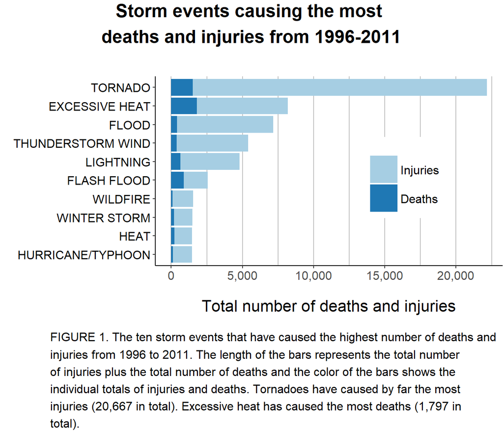

```r
# health.levels is a vector of factor levels to be used to make
# the plot pretty later
health.levels <- p3 %>%
        filter(FATALITIES > 0 | INJURIES > 0) %>%
        group_by(EVTYPE) %>%
        summarize(grand.total = sum(FATALITIES + INJURIES)) %>%
        arrange(grand.total) %>%
        pull(EVTYPE) %>%
        as.character()

# health2 is a data frame containing the ten storm types that
# cause the most fatalities + injuries
library(tidyr)
health2 <- p3 %>%
        filter(FATALITIES > 0 | INJURIES > 0) %>%
        group_by(EVTYPE) %>%
        summarize(fatalities = sum(FATALITIES),
                  injuries = sum(INJURIES),
                  grand.total = sum(FATALITIES, INJURIES)) %>%
        arrange(desc(grand.total)) %>%
        gather("inj.fat", "count", fatalities, injuries) %>% # gather fatalities, injuries into key/value pair
        arrange(desc(grand.total)) %>%
        head(20) %>% # filter top ten storm types
        mutate(EVTYPE = factor(EVTYPE, levels = health.levels), # Put factor levels in decreasing order
               inj.fat = factor(inj.fat, levels = c("injuries", "fatalities"))) %>%
        select(-grand.total)


# Make a plot showing the ten storm event types that cause the most
# combined fatalities and injuries, broken down by fatalities and
# injuries for each storm event type.

library(ggplot2)
library(gridExtra)
library(grid)
library(RColorBrewer)
library(scales)

# theme simply stores all the information to make the plot look pretty
theme <- theme_classic() +
        theme(legend.position = c(.6,.25),
              legend.justification = c(0,0),
              legend.key.size = unit(2, "lines"),
              legend.text = element_text(size = 12),
              axis.text.y = element_text(color = "black"),
              axis.title.x = element_text(size = 16,
                                          margin = margin(20, 0, 0, 0)),
              plot.title = element_text(size = 18,
                                        face = "bold",
                                        hjust = 0,
                                        margin = margin(0, 0, 30, 0)),
              axis.text = element_text(size = 12),
              panel.grid.major.x = element_line(color = "gray"),
              panel.grid.minor.x = element_line(color = "gray"),
              plot.caption = element_text(hjust = 0,
                                          margin = margin(20, 0, 0, 0)),
              plot.margin = margin(30,0,15,0))

# title1, plot1, and caption1 will be arguments in grid.arrange()
captionA <- "FIGURE 1.  The ten storm events that have caused the highest number of deaths and injuries from
1996 to 2011. The length of the bars represents the total number of injuries plus the total number of deaths and
the color of the bars shows the individual totals of injuries and deaths. Tornadoes have caused by far the most
injuries (20,667 in total). Excessive heat has caused the most deaths (1,797 in total)."
title1 <- textGrob("Storm events causing the most \ndeaths and injuries from 1996-2011",
                   x = unit(.5, "npc"),
                   just = c("center"),
                   gp = gpar(fontsize = 18,
                             fontface = "bold"))
plot1 <- ggplot(health2, aes(EVTYPE, count)) +
        geom_bar(stat = "identity",
                 aes(fill = inj.fat)) +
        labs(x = "",
             y = "Total number of deaths and injuries") +
        scale_fill_brewer(name = "",
                          labels = c("Injuries", "Deaths"),
                          palette = "Paired") +
        scale_y_continuous(labels = comma) +
        coord_flip() +
        theme
caption1 <- textGrob(str_wrap(captionA),
                     x = unit(0.1, "npc"),
                     just = "left")

# Here's the actual plot
grid.arrange(plot1, top = title1, bottom = caption1)
```

As the caption explains, tornadoes have caused by far the most number of injuries from 1996-2011, while excessive heat has caused the most number of deaths. Note that “excessive heat” and “heat” both show up in the top ten storm types that are harmful to public health. They are, in fact, classified differently in the storm database. “Heat” occurs when the heat index is between 100 and 105 degrees Fahrenheit. “Excessive heat” occurs when the heat index reaches or exceeds 105 degrees Fahrenheit.

The same approach was used to answer the second question. The ten storm types that have caused the most property and crop damage from 1996-2011 are shown in the following plot (after the code):

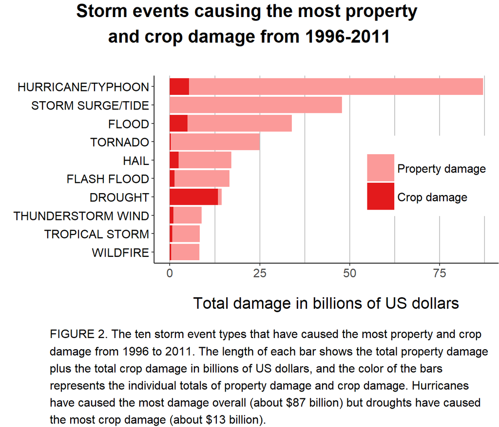

```r
# Calculate damage statistics for all EVTYPEs
damage <- p3 %>%
        filter(total.dmg > 0) %>%
        group_by(EVTYPE) %>%
        summarize(total.prop = sum(prop.dmg),
                  total.crop = sum(crop.dmg)) %>%
        mutate(grand.total = total.prop + total.crop) %>%
        arrange(desc(grand.total))

damage.levels <- damage[1:10,] %>% # Create vector of EVTYPE factor levels
        arrange(grand.total) %>%
        pull(EVTYPE) %>%
        as.character

# damage is a data frame that contains the ten storm types which have
# caused the most damage from 1996-2011
damage <- damage[1:10,] %>%
        mutate(EVTYPE = factor(EVTYPE, levels = damage.levels)) %>%
        gather("damage.type", "cost", total.crop, total.prop) %>%
        mutate(damage.type = factor(damage.type, levels = c("total.prop", "total.crop"))) %>%
        arrange(desc(grand.total))

# Make the plot
pal <- brewer.pal(6, "Paired")[5:6]
captionB <- "FIGURE 2.  The ten storm event types that have caused the most property and crop damage from 1996 to
2011. The length of each bar shows the total property damage plus the total crop damage in billions of US dollars, and
the color of the bars represents the individual totals of property damage and crop damage.
Hurricanes have caused the most damage overall (about $87 billion) but droughts have caused the most crop
damage (about $13 billion)."
title2 <- textGrob("Storm events causing the most property \nand crop damage from 1996-2011",
                   x = unit(.5, "npc"),
                   just = c("center"),
                   gp = gpar(fontsize = 18,
                             fontface = "bold"))
plot2 <- ggplot(damage, aes(EVTYPE, cost/1e9)) +
        geom_bar(stat = "identity",
                 aes(fill = damage.type)) +
        labs(x = "",
             y = "Total damage in billions of US dollars") +
        scale_fill_manual(name = "",
                          labels = c("Property damage", "Crop damage"),
                          values = pal) +
        coord_flip() +
        theme
caption2 <- textGrob(str_wrap(captionB),
                     x = unit(0.1, "npc"),
                     just = c("left"))

# Here's the plot.
grid.arrange(plot2, top = title2, bottom = caption2)
```

As explained in the caption, hurricanes have caused the most total damage from 1996-2011, and the bulk of this damage came from property damage. Droughts, however, have caused much more crop damage than any other type of weather event. Not surprisingly, many of the storm types were present in both plots, indicating that the types of storms that tend to cause a lot of damage tend to be the same types of storms that injure and kill people.

For more information about the storm database, you can visit the [NOAA](https://www.ncdc.noaa.gov/stormevents/details.jsp?type=eventtype) website. You can also visit my [Github repository](https://github.com/pratta3/RR-Coursera-Project-02) to browse the detailed history of the analysis.